# Reproducible Research: Course Project 1

October 18, 2020

### Load the data

```r
fileUrl <- "https://d396qusza40orc.cloudfront.net/repdata%2Fdata%2Factivity.zip"
download.file(fileUrl,destfile="./data/activity.zip",method="curl")

unzip(zipfile="./data/activity.zip",exdir="./data")
data <- read.csv("./data/activity.csv")
data$date <- as.Date(data$date)
```

### Find the mean total number of steps taken per day

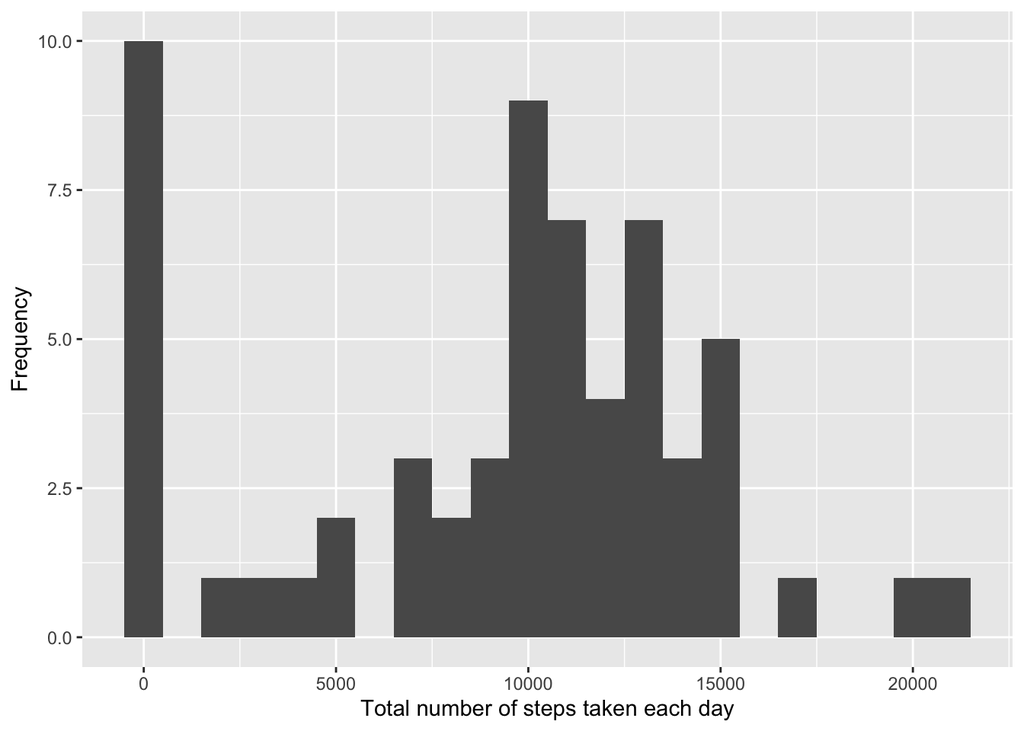

```r
options(warn=-1)
library(ggplot2)
total_steps <- tapply(data$steps, data$date, FUN=sum, na.rm=TRUE)
qplot(total_steps, binwidth=1000, xlab="Total number of steps taken each day",
      ylab = "Frequency")
```

```r
mean(total_steps, na.rm=TRUE)
```

```
## [1] 9354.23
```

```r
median(total_steps, na.rm=TRUE)
```

```
## [1] 10395
```

### Find the average daily activity pattern

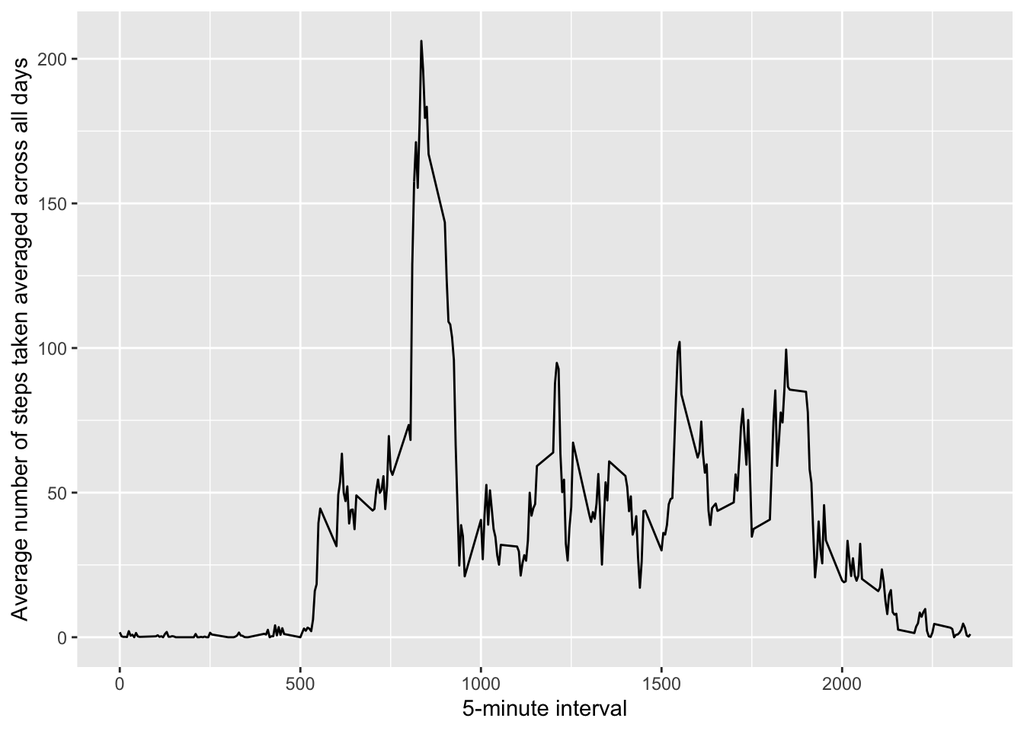

```r
library(ggplot2)
aver <- aggregate(x=list(steps=data$steps), by=list(interval=data$interval),
                      FUN=mean, na.rm=TRUE)
g<-ggplot(data=aver, aes(x=interval, y=steps))
  g+ geom_line() +xlab("5-minute interval") +
    ylab("Average number of steps taken averaged across all days")
```

We now find which 5-minute interval, on average across all the days in the dataset, contains the maximum number of steps.

```r
aver[which.max(aver$steps),]
```

```
##     interval    steps
## 104      835 206.1698
```

### Impute missing values

There are many days/intervals where there are missing values (coded as `NA`) which may lead to bias in results. We first calculate the total number of missing values in the dataset.

```r
missing <- is.na(data$steps)
table(missing)
```

```
## missing
## FALSE  TRUE
## 15264  2304
```

We then replace the missing values with the mean value of that 5-minute interval.

```r
fill.value <- function(steps, interval) {
    filled <- NA
    if (!is.na(steps))
        filled <- c(steps)
    else
        filled <- (aver[aver$interval==interval, "steps"])
    return(filled)
}
data_filled<- data
data_filled$steps <- mapply(fill.value, data_filled$steps, data_filled$interval)
```

We now create a histogram of the total number of steps taken each day and calculate the mean and median of the total number of steps, using the imputed dataset.

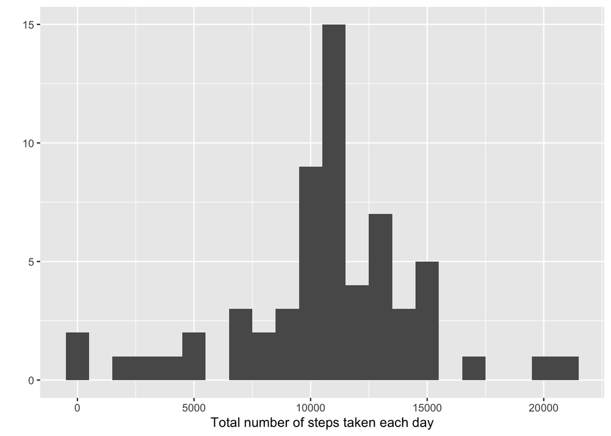

```r
total_steps <- tapply(data_filled$steps, data_filled$date, FUN=sum)
qplot(total_steps, binwidth=1000, xlab="Total number of steps taken each day")
```

```r
mean(total_steps)
```

```
## [1] 10766.19
```

```r
median(total_steps)
```

```
## [1] 10766.19
```

The mean and median values have increased after imputing missing data since in the original data, there are some days with `steps` values `NA` for any `interval`. The total number of steps taken in such days are set to 0 by default. However, after replacing missing `steps` values with the mean `steps` of associated `interval` value, those 0 values are removed from the histogram of total number of steps taken each day.

### Check any difference in activity patterns between weekdays and weekends

We first find the day of the week for each measurement in the dataset. To this aim, we use the dataset with the imputed values.

```r
Wday_OR_Wend <- function(date) {
    day <- weekdays(date)
    if (day %in% c("Monday", "Tuesday", "Wednesday", "Thursday", "Friday"))
        return("weekday")
    else if (day %in% c("Saturday", "Sunday"))
        return("weekend")
}
data_filled$date <- as.Date(data_filled$date)
data_filled$day <- sapply(data_filled$date, FUN=Wday_OR_Wend)
```

We now create a panel plot which includes the plots of the average number of steps taken on weekdays and weekends.

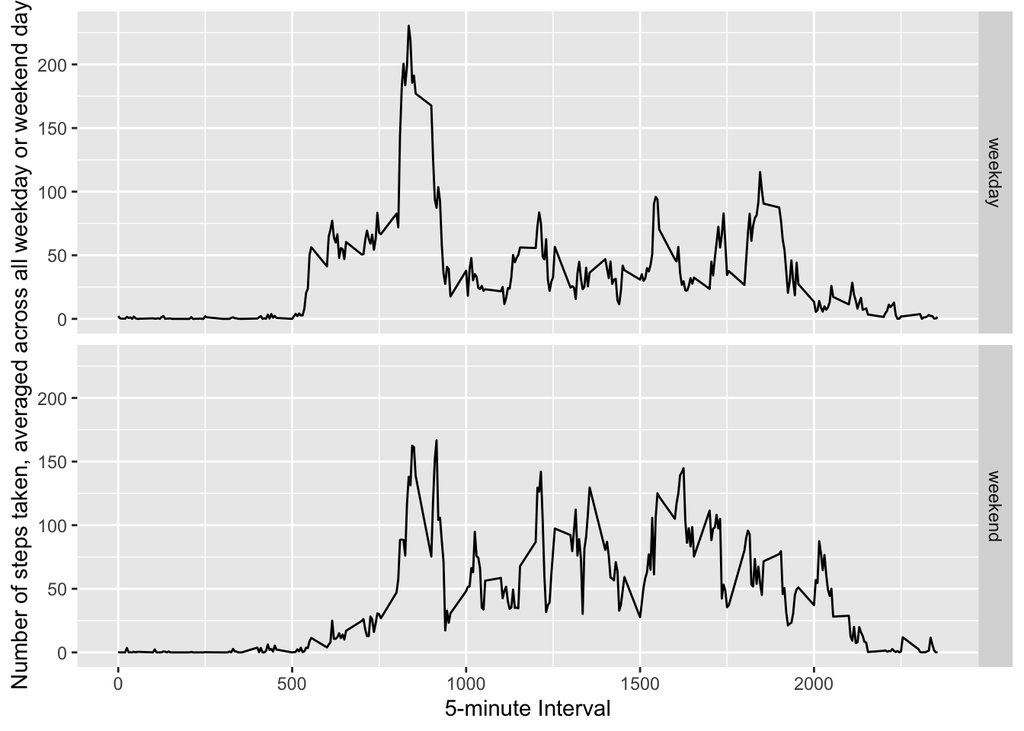

```r
aver <- aggregate(steps ~ interval + day, data=data_filled, mean)
g<-ggplot(aver, aes(interval, steps))
g+ geom_line() + facet_grid(day ~ .) +xlab("5-minute Interval") +
  ylab("Number of steps taken, averaged across all weekday or weekend days")
```